# Leaders and Laggards - Data Analysis

**Purpose**

This document provides a reproducible analysis of how Sweden’s 20 largest industrial emitters engage with the mission to reach net-zero emissions by 2045. We integrate official emissions statistics, project-level funding data from Industry Leap and Climate Leap, and collaboration patterns derived from social network analysis to evaluate each firm’s ambition, technological pathway, targeted emission scope, engagement (public funding captured), and collaborations.

Two headline results emerge. First, stated ambition levels are a poor proxy for action: several firms with high-profile net-zero targets show limited programme participation, while a subset of medium-ambition incumbents are central, well-funded participants. Second, incumbents do not behave as simple “leaders” or “laggards.” Instead, we identify four strategic roles—transformative frontrunners, system enablers, adaptive followers, and peripheral bystanders—that better capture how incumbents mobilise resources and shape system change.

By making the data, code, and figures transparent, the analysis aims to move policy and research debates beyond ambition statements toward observable engagement and collaboration, helping to design instruments that (i) reward concrete participation aligned with mission goals, (ii) foster shared infrastructures, and (iii) tailor support and pressure to heterogeneous incumbent roles.

**Structure of the analysis**

This document is organised into six steps: 1. Data import — emissions, climate ambitions, project participation, collaborations, and actor categories. 2. Data preparation — cleaning and harmonising datasets for consistent identifiers and categories. 3. Analysis A: Ambition vs. Engagement — linking firms’ stated ambitions to emissions and public funding, and clustering participation profiles. 4. Analysis B: Pathways × Scopes — mapping technological solution pathways against targeted emission scopes and identifying investment communities. 5. Analysis C: Collaboration networks — constructing and analysing actor networks to assess the centrality and roles of main emitters. 6. Outputs — figures, tables, and metrics that reproduce results presented in the associated manuscript and appendix.

# 1 Libraries

# 2 Data sources

The analysis draws on six prepared datasets: 1. Emission statistics (2022) from Naturvårdsverket (Swedish EPA). 2. Climate ambitions of the 20 main emitters, manually coded from corporate reports, SBTi, and other public sources. 3. Projects funded under Industry Leap and Climate Leap that include at least one main emitter, categorised by technological pathway and targeted emission scope. 4. Collaborations linking emitters to partners, with financial engagement classified as targeting own, others’, or negative emissions. 5. Actor categories assigning all participants to types such as emitter, university, new entrant, or intermediary. 6. Appendix data with the full list of projects involving main emitters.

All datasets are stored in the data_prepared/ folder and read into R for cleaning and analysis.

# 3 Identify main emitters from emission statistics and their engagement from collaboration data

We begin by selecting Sweden’s 20 largest industrial emitters, based on aggregated 2022 emissions reported by Naturvårdsverket (Swedish EPA). To assess how these firms engage with decarbonisation programmes, we combine the emission data with collaboration records from Industry Leap and Climate Leap, summing all public funding linked to each firm. This allows us to calculate both absolute engagement (MSEK of support received) and funding intensity (SEK per tonne of CO₂ emitted). The merged dataset provides the foundation for Analysis A, where we examine how climate ambitions relate to actual programme participation.

```r
# Aggregate emissions by firm and select top 20
main_emitters_emissions <- emission_statistics %>%
  group_by(name, industry) %>%
  summarise(ktco2 =round(sum(fossil_t_co2)/1e3)) %>% ungroup()%>%
  slice_max(order_by= ktco2, n=20)

# Calculate engagement (SEK / MSEK) from collaboration data
engagement <- collaborations %>%
  group_by(name) %>%
  summarise(engagement_MSEK = round(sum(engagement)/1e6), engagement_SEK = sum(engagement)) %>%
  arrange((desc(engagement_MSEK))) %>%
  mutate(main_emitter = name %in% main_emitters_emissions$name)

# Merge emissions and engagement, calculate funding intensity (SEK per tonne CO2)
main_emitters <- main_emitters_emissions %>%
  left_join(engagement) %>%
  mutate(SEK_per_ton = round(engagement_SEK/(1000*ktco2)))

main_emitters %>%
  select(-c(main_emitter, engagement_SEK)) %>%
  gt(rownames_to_stub = T) %>%
  # Clean column labels
  cols_label(
    name            = "Emitter",
    industry        = "Industry",
    ktco2           = "Emissions (ktCO₂)",
    engagement_MSEK = "Engagement (MSEK)",
    SEK_per_ton     = "SEK per ton CO₂"
  ) %>%
  # Format large numbers with separators
  fmt_number(
    columns = c(ktco2, engagement_MSEK, SEK_per_ton),
    decimals = 0,
    use_seps = TRUE
  ) %>%
  # Add a summary row with totals
  grand_summary_rows(
    fns = list(Total = ~sum(.)),
    columns = c(ktco2, engagement_MSEK),
    formatter = fmt_number,
    decimals = 0,
    use_seps = TRUE
  ) %>%
  tab_options(
    table.font.size = "small",
    data_row.padding = px(3)
  )
```

Table 1: Table 1. Sweden’s 20 largest industrial emitters (2022), their cumulative public funding engagement (MSEK), and funding intensity (SEK per ton CO₂).

|  | Emitter | Industry | Emissions (ktCO₂) | Engagement (MSEK) | SEK per ton CO₂ |
| --- | --- | --- | --- | --- | --- |
| 1 | SSAB | Iron and steel | 5,004 | 33 | 7 |
| 2 | Preem | Refinery | 1,971 | 7 | 3 |
| 3 | Heidelberg Materials | Cement and minerals | 1,754 | 310 | 177 |
| 4 | LKAB | Iron and steel | 597 | 3,344 | 5,601 |
| 5 | St1 | Refinery | 569 | 117 | 206 |
| 6 | Borealis | Chemicals | 528 | 77 | 145 |
| 7 | Stockholm Exergi | Heat and power | 471 | 144 | 306 |
| 8 | E.ON | Heat and power | 439 | 4 | 8 |
| 9 | Boliden | Metals | 301 | 119 | 396 |
| 10 | Tekniska verken i Linköping | Heat and power | 294 | 392 | 1,334 |
| 11 | Sysav | Heat and power | 283 | 7 | 23 |
| 12 | SMA Mineral | Cement and minerals | 269 | 0 | 0 |
| 13 | Renova | Heat and power | 223 | 0 | 2 |
| 14 | Kubal | Metals | 218 | 76 | 348 |
| 15 | Vargön Alloys | Metals | 197 | 3 | 13 |
| 16 | Höganäs | Iron and steel | 193 | 4 | 23 |
| 17 | Nordkalk | Cement and minerals | 190 | 20 | 106 |
| 18 | Vattenfall | Heat and power | 182 | 160 | 877 |
| 19 | Outokumpu | Iron and steel | 176 | 27 | 151 |
| 20 | Uniper | Heat and power | 176 | 155 | 878 |
| Total | — | — | 14,035 | 4,999 | — |

# 4 Analysis A: Ambition vs. engagement

We link firms’ stated climate ambition (Low/Medium/High) to their cumulative public funding (MSEK) to examine whether higher ambition corresponds to greater engagement in public decarbonization programes. We then cluster firms by emissions and engagement to reveal distinct participation profiles.

This analysis produces two figures that are used in the paper:

1. Figure 2. Public funding engagement of main emitters by climate ambition level
2. Figure 3: Clustering of main emitters

## 4.1 Public funding engagement of main emitters by climate ambition level (Figure 2 in paper)

To compare main emitters’ stated climate ambitions with their actual engagement in public decarbonization programes, we link the ambition categories (Low, Medium, High) to the dataset of 20 main emitters and their cumulative public funding.

The figure shows the distribution of funding (MSEK) across ambition levels. Ambitions are ordered from Low to High, while engagement is shown on a logarithmic scale to account for the skewed distribution of funding. Each boxplot displays the spread of funding within each ambition category, and points represent individual firms. Labels are added to highlight specific firm names.

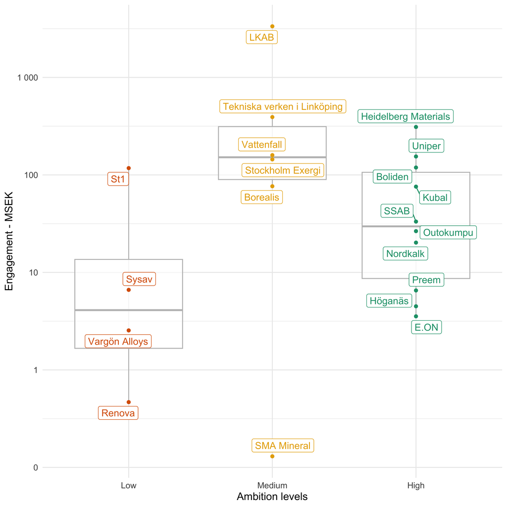

Figure 1: Engagement in public decarbonisation programmes (measured as total public funding in MSEK) across the 20 main emitters, grouped by stated climate ambition levels (Low = red, Medium = orange, High = green). Engagement values are displayed on a logarithmic scale to account for the skewed distribution of funding. Boxplots indicate the spread of funding within each ambition category, while individual points represent firms. Labels highlight the names of specific firms to illustrate variation within and between ambition groups.

```r
# Merge ambition categories with main emitters and their engagement
ambitions <- main_emitters %>%
  left_join(main_emitters_ambitions)

# Prepare plotting data: ensure ambition factor is ordered Low → Medium → High
amb_box_data <- ambitions %>%
  mutate(ambition = as.factor(ambition)) %>%
  mutate(ambition = fct_relevel(ambition, c("Low", "Medium", "High")))


# Plot boxplots of engagement (MSEK, log scale) by ambition level
amb_box_data %>%
  ggplot(aes(ambition, engagement_SEK/1e6,
             color = ambition,
             label = name)) +
  geom_boxplot(alpha = 0.6, show.legend = F,color = "grey") +
  geom_point(show.legend = F) +
  scale_y_log10(labels=scales::number_format(accuracy = 1))+
  scale_color_manual(
  name = "Ambition",
  values = c("Low" = "#D95F02", "Medium" = "#E6AB02", "High" = "#1B9E77")
)+
  geom_label_repel(show.legend = F) +
  labs(x= "Ambition levels", y = "Engagement - MSEK")+
  theme_minimal() +
  theme(plot.background = element_rect(colour = "white"),
        text = element_text(size = 12))
```

## 4.2 Clustering of main emitters

Since ambition levels alone do not explain variation in firms’ actual engagement, we apply a clustering analysis to identify distinct patterns. We use k-means clustering on two variables: each firm’s total annual emissions (ktCO₂e) and cumulative public funding received (MSEK). Both variables are log-transformed to reduce skewness.

The optimal number of clusters was determined using the silhouette and within-cluster sum of squares (WSS) methods, both pointing to three clusters. Figure 3 visualises the resulting groups (A1–A3), which represent different engagement–emissions profiles among the 20 main emitters.

### 4.2.1 Identifying appropriate number of clusters

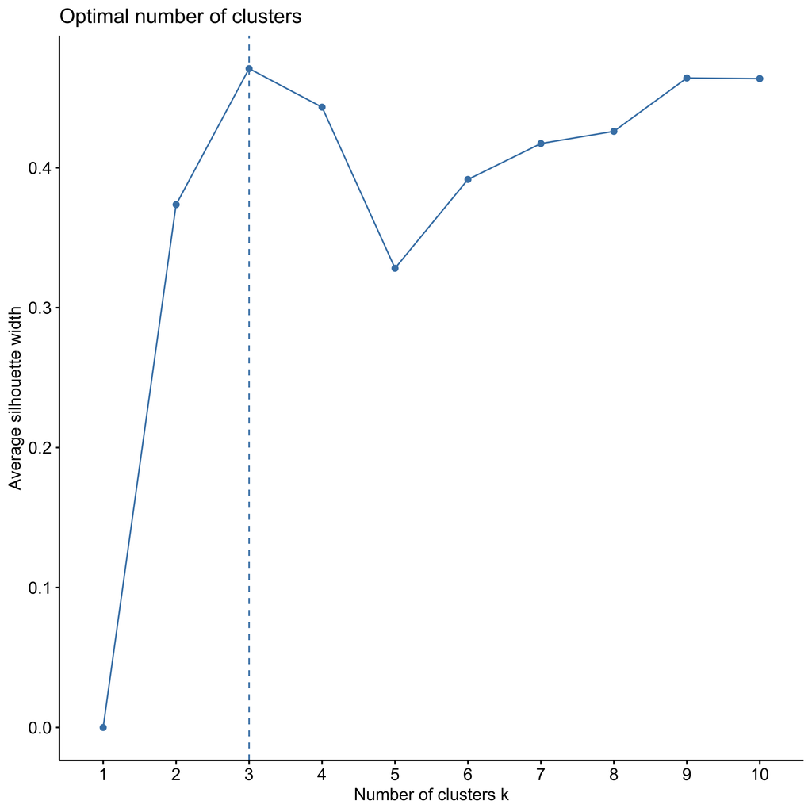

Silhouette

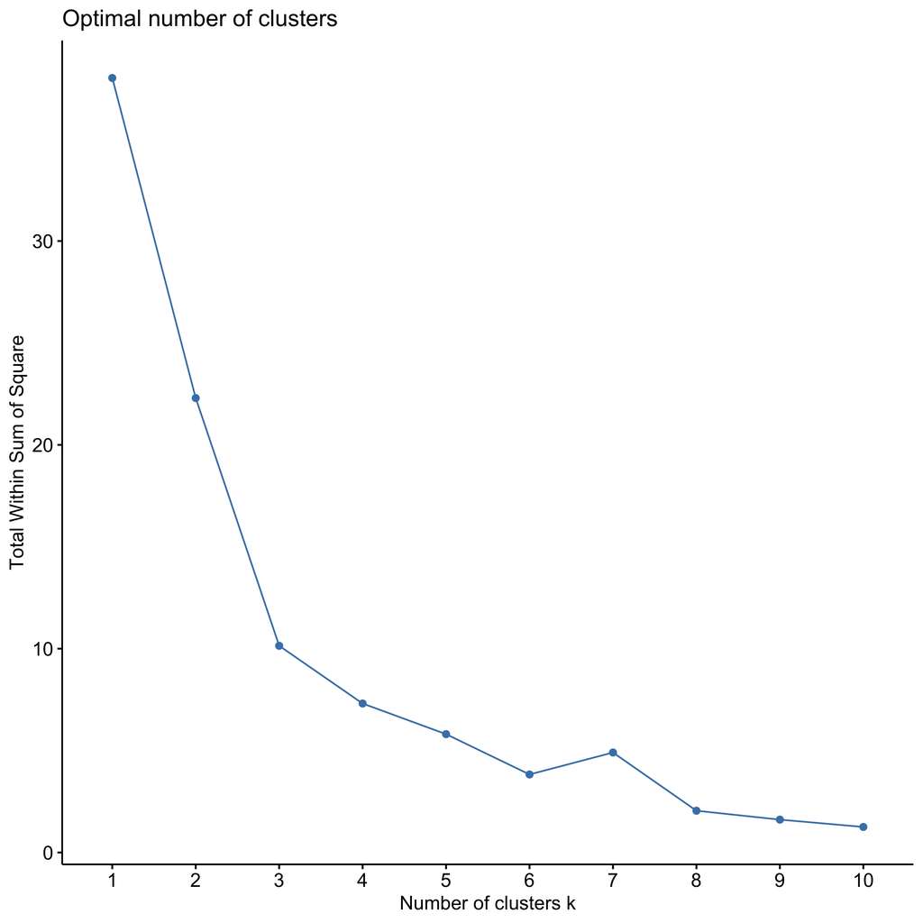

WSS

```r
# Prepare clustering input: log-transform emissions and engagement
cluster_input <- ambitions %>%
  mutate(log_ktco2 = log(ktco2),
         log_msek  = log(engagement_MSEK + 1)) %>%
  select(starts_with("log")) %>%
  scale()

# Assess number of clusters (silhouette + WSS)
fviz_nbclust(cluster_input, kmeans, method = "silhouette")
fviz_nbclust(cluster_input, kmeans, method = "wss")

# Apply k-means clustering with 3 centers (identified as optimal)
set.seed(42)
kmeans_result <- kmeans(cluster_input, centers = 3)


# Add cluster assignments to dataset
ambitions$cluster <- as.factor(kmeans_result$cluster)
```

Cluster selection diagnostics for k-means on log-ktCO₂e and log-MSEK.

### 4.2.2 Plotting the Clusters (Figure 3 in paper)

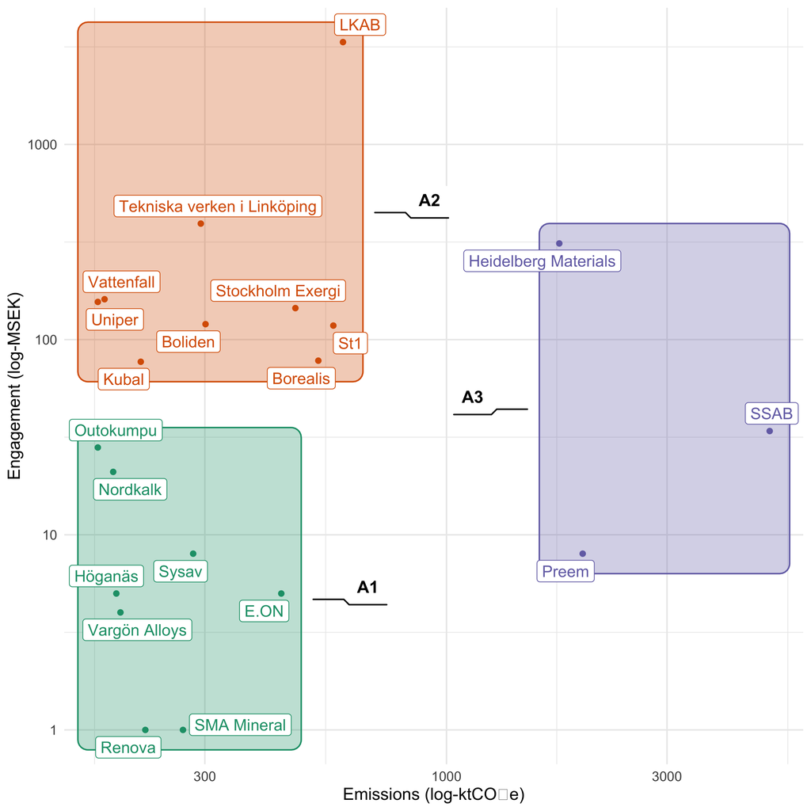

Figure 2: Clustering of main emitters (A1–A3) based on total emissions (log-ktCO₂e) and cumulative public funding received (log-MSEK). The k-means algorithm groups firms into three distinct profiles: A1 = low emissions and low engagement, A2 = low emissions and high engagement, A3 = high emissions with varied engagement.

```r
# Prepare data for plotting
amb_plot_data <- ambitions %>%
  select(name, ambition, cluster, msek = engagement_MSEK, ktco2)

# Plot firms by emissions (x) and engagement (y), highlighting clusters A1–A3
amb_plot_data %>%
  mutate(msek = msek + 1) %>%
  ggplot(aes(ktco2, msek, color = cluster, label = name)) +
  geom_mark_rect(aes(fill = cluster, label = paste0("A", cluster))) +
  geom_point() +
  geom_label_repel(size = 4, show.legend = FALSE) +
  scale_x_log10() +
  scale_y_log10() +
  scale_color_brewer(palette = "Dark2") +
  scale_fill_brewer(palette = "Dark2") +
  theme_minimal() +
  theme(plot.background = element_rect(colour = "white"),
        legend.position = "none",
        text = element_text(size = 12)) +
  labs(x = "Emissions (log-ktCO₂e)", y = "Engagement (log-MSEK)")
```

# 5 Analysis B: Solution pathways and emissions scopes of investments

We map each main emitter’s public funding to solution pathways (e.g., Electricity & hydrogen, CCS, Recycling, Energy efficiency, BECCS, DAC, CCU, WtE‑CCS, Bio‑CCU, Biofuels & biomass, Other) and the emissions scopes they target (Scope 1–3, Infrastructure, Others). We then build a two‑mode network connecting emitters and pathway–scope combinations, with edge weights given by cumulative funding (SEK). The resulting layout and community detection (B1–B7) reveal how emitters concentrate funding across technological pathways and scopes.

## 5.1 Data preparation: pathway × scope funding per emitter

```r
# Sum engagement per (project, emitter)
emitters_project_engagement <- collaborations %>%
  group_by(projectnr, name) %>%
  summarise(sek = sum(engagement))

# Unique (project, emitter, pathway, scope) combos + join fun
scope_pathway <- emitters_project %>%
  select(projectnr, name, pathway = pathway, scope) %>%
  distinct() %>%
  left_join(emitters_project_engagement) %>%
  group_by(name, pathway, scope) %>%
  summarise(sek = sum(sek)) %>%
  filter(sek >0) #Remove pathways with no funding

# Wide table (emitters × pathway: scope), zeros for missing
sp_wide<- scope_pathway %>%
  pivot_wider(names_from = pathway:scope, values_from = sek,
              names_sep = ": ") %>%
  mutate(across(where(is.numeric), ~replace_na(., 0))) %>%
  ungroup()
str(sp_wide)
```

```
tibble [20 × 23] (S3: tbl_df/tbl/data.frame)
 $ name                             : chr [1:20] "Boliden" "Borealis" "E.ON" "Heidelberg Materials" ...
 $ Electricity and hydrogen: Scope 1: num [1:20] 6.7e+07 0.0 0.0 0.0 0.0 ...
 $ Energy efficiency: Others        : num [1:20] 46550000 0 1214615 0 1530000 ...
 $ Energy efficiency: Scope 2       : num [1:20] 5600000 0 0 0 0 0 0 0 0 0 ...
 $ Recycling: Scope 1               : num [1:20] 0 76541625 0 0 0 ...
 $ BECSS: Scope 1                   : num [1:20] 0 0 1410000 0 0 0 0 0 0 0 ...
 $ Biofuels and biomass: Others     : num [1:20] 0 0 659750 0 0 ...
 $ CCS: Infrastructure              : num [1:20] 0 0 262000 0 51500 ...
 $ CCS: Scope 1                     : num [1:20] 0.00 0.00 0.00 3.09e+08 0.00 ...
 $ Energy efficiency: Scope 1       : num [1:20] 0 0 0 1200000 0 0 0 0 0 0 ...
 $ Biofuels and biomass: Scope 1    : num [1:20] 0 0 0 0 2912934 ...
 $ CCS: Others                      : num [1:20] 0 0 0 0 0 0 0 130000 0 0 ...
 $ Energy efficiency: Scope 3       : num [1:20] 0 0 0 0 0 0 0 0 50400 0 ...
 $ Electricity and hydrogen: Scope 2: num [1:20] 0 0 0 0 0 0 0 0 0 0 ...
 $ Electricity and hydrogen: Scope 3: num [1:20] 0 0 0 0 0 0 0 0 0 0 ...
 $ Biofuels and biomass: Scope 2    : num [1:20] 0 0 0 0 0 0 0 0 0 0 ...
 $ Recycling: Scope 3               : num [1:20] 0 0 0 0 0 0 0 0 0 0 ...
 $ WtE-CSS: Scope 1                 : num [1:20] 0 0 0 0 0 0 0 0 0 0 ...
 $ Bio-CCU: Scope 3                 : num [1:20] 0 0 0 0 0 0 0 0 0 0 ...
 $ Biofuels and biomass: Scope 3    : num [1:20] 0 0 0 0 0 0 0 0 0 0 ...
 $ CCU: Others                      : num [1:20] 0 0 0 0 0 0 0 0 0 0 ...
 $ Recycling: Others                : num [1:20] 0 0 0 0 0 0 0 0 0 0 ...
 $ Electricity and hydrogen: Others : num [1:20] 0 0 0 0 0 0 0 0 0 0 ...
```

## 5.2 Emitter–pathway network (Figure 4 in paper)

```r
# Long table for network edges (emitters ↔ pathway:scope)
sp_long<- sp_wide %>%
  pivot_longer(-name, names_to = "Tech", values_to = "sek") %>%
  filter(sek >0)

# Totals for node sizing
tot_sek <- sp_long %>%
  group_by(name) %>%
  summarise(tot_sek = sum(sek))

tot_sek_tech <- sp_long %>%
  group_by(Tech) %>%
  summarise(tot_sek = sum(sek)) %>%
  rename(name = Tech)

tot_data <- bind_rows(tot_sek, tot_sek_tech)

# Build two-mode graph (emitters + pathway:scope nodes)
set.seed(1223)
g_sp<- as_tbl_graph(sp_long, directed = FALSE) %N>%
  mutate(type = ifelse(name %in% sp_long$name, TRUE, FALSE)) %>%
  left_join(tot_data) %>%
  mutate(degree = centrality_degree(),
         cl = group_fast_greedy(weights = log(sek)))

sp_nodes <- g_sp %N>% as_tibble()
sp_edges <- g_sp %E>% as_tibble()

pal <- RColorBrewer::brewer.pal(8, "Dark2")

set.seed(132)
g_sp %>%
  ggraph(layout = "nicely")+
  geom_edge_link(aes(edge_width = log(sek)),
                 edge_alpha = 0.4,
                 color = "grey", show.legend = FALSE) +
  geom_node_point(aes(size = log(tot_sek),
                      color = as.factor(cl),
                      shape= type),
                  fill = "white", alpha = 0.9, show.legend = T) +
  geom_node_text(aes(label = str_wrap(name, 20)),
                 repel = TRUE, size = 3.5)+
  scale_edge_width(range = c(0.5, 3))+
  scale_color_manual(values = pal, labels = paste0("B",1:7))+
  scale_size(range = c(2,6))+
  theme_graph() +
  labs(title = "")+
  guides(color = guide_legend(title = "Cluster:", nrow = 1),
         shape = "none",
         alpha = "none",
         size = "none",
         edge_width = "none",
         edge_alpha = "none")+
theme(legend.position = 'bottom',
      text = element_text(size = 12),
      legend.margin = margin(t = -10, unit = "pt"))
```

[figure not shown]

Figure 3: Network of main emitters and pathway–scope investments. Nodes are emitters and pathway–scope categories; edges are weighted by cumulative funding (SEK). Node size indicates total funding; colours indicate community detection (B1–B7).

# 6 Analysis C: Collaborations and Engagement

In the final step, we examine how main emitters are embedded in the wider network of actors participating in publicly funded decarbonisation projects. We construct a one-mode actor network in which nodes represent organisations (emitters and their collaborators), and edges capture co-participation in projects. This enables us to assess both the breadth of collaborative ties and the centrality of emitters in the network.

The first figure visualises the resulting actor network. Main emitters are highlighted and labelled, while other actors are coloured by type (e.g., industrial firms, universities, partnerships, intermediaries). Node size indicates degree centrality, and edge thickness reflects the number of shared projects. The network shows that while some emitters are highly central and well-connected, others remain more peripheral.

We then calculate a set of network statistics (e.g., density, clustering, average path length) to summarise structural properties of the collaboration network. To contextualise these measures, we compare the observed network with a null model of randomly generated networks with the same number of nodes and edges. This baseline allows us to assess whether the observed network exhibits higher clustering or shorter paths than expected by chance.

Finally, we cluster main emitters based on their collaborative embeddedness (degree centrality) and their level of public funding engagement (MSEK). The resulting groups (C1–C7), shown in the second figure, highlight distinct participation profiles ranging from “high collaboration and very high engagement” to “low collaboration and very low engagement.” These clusters illustrate how firms differ not only in the amount of funding they capture, but also in how embedded they are within collaborative structures.

## 6.1 One mode network (Figure 5 in paper)

```r
# Input edges (project ↔ actor)
df_g <- collaborations %>%
  select(projectnr, name, engagement)

# Create a bipartite graph (two-mode network) between projects and actor
g_project <- as_tbl_graph(df_g, directed = FALSE) %>%
  mutate(type = if_else(name %in% df_g$name, TRUE, FALSE)) # TRUE = actor, FALSE = project

# Convert to onemode network
firms_firm <- igraph::bipartite_projection(g_project)$proj2

# Add engagement (SEK)
add_engagement <- collaborations %>%
  group_by(name) %>%
  summarise(sek_tot = sum(engagement))

# Create network and calculate key meassures
gs <- as_tbl_graph(firms_firm) %N>%
  mutate(main_emitter = if_else(name %in% main_emitters$name, TRUE, FALSE)) %>%
  left_join(add_engagement) %>%
  left_join(actors) %>%
  filter(main_emitter | sek_tot >0) %>%
  mutate(degree = centrality_degree(mode = "all"),
         betweenness = centrality_betweenness(),
         authority = centrality_authority()
         )

nodes <- gs %N>% as_tibble() %>%  arrange(degree, betweenness, authority)
edges <- gs %E>% as_tibble()

#nn <- nodes %>% rowid_to_column("id") %>% select(id, name)
#edges_named <- edges %>% left_join(nn, by = c("from" = "id")) %>% rename(source = name) %>% left_join(nn, by = c("to" = "id")) %>% rename(target = name) %>% select(source, target, weight)

type_pal <- c("#000000", "#808080", "#E69F00", "#56B4E9", "#CC79A7", "#F0E442", "#0072B2")
ind_n <- c("Main industrial emitter", "Industrial emitter", "Other firm", "Innovation partnership", "New entrant", "University or research institute", "Government or intermediary")
names(type_pal)<-ind_n

set.seed(111)
ggraph(gs, layout = "fr") +
  geom_edge_link(aes(edge_alpha = 0.4, edge_width = weight),
                 color = "grey", show.legend = FALSE) + # Edge attributes
  geom_node_point(aes(color = industry_actor_type,
                      size = degree, shape= main_emitter), fill = "white", alpha = 0.9, show.legend = T) + # Node attributes
  geom_node_text(aes(label = if_else(main_emitter,
                                     str_wrap(name, 15),
                                     str_trunc(name, 20,
                                               ellipsis = ".")),
                     size = if_else(main_emitter, 4.5, 1.5),
                     fontface = if_else(main_emitter, "bold", "plain")),
                 repel = TRUE) +
  scale_edge_width(range = c(0.5, 2))+
  scale_color_manual(values = type_pal)+
  scale_size(range = c(2,6))+
  theme_graph() +
  guides(color = guide_legend(title = "Industry actor type:"),
         shape = guide_legend(title = "Main emitter:"),
         alpha = "none",
         size = "none",
         edge_width = "none",
         edge_alpha = "none")+
  theme(text = element_text(size = 12))
```

[figure not shown]

Actor network of funded projects that include at least one main emitter. Nodes are actors; edges connect co-participating actors, weighted by the number of shared projects. Colour indicates actor type; shape flags main emitters; node size reflects degree.

## 6.2 Calculate Network Characteristics

```r
ig <- as.igraph(gs)

# Core metrics on the observed graph
network_stats <- list(
  num_nodes = gorder(ig),
  num_edges = gsize(ig),
  density = round(edge_density(ig), 3),
  diameter = diameter(ig, directed = FALSE, unconnected = TRUE),
  avg_path_length = round(mean_distance(ig, directed = FALSE, unconnected = TRUE), 1),
  transitivity_global = round(transitivity(ig, type = "global"), 2),
  num_components = components(ig)$no,
  largest_component_size = max(components(ig)$csize),
  avg_degree = round(mean(degree(ig)), 1)
)

# Mapping of metric names to descriptive labels
labels <- c(
  num_nodes = "Number of nodes",
  num_edges = "Number of edges",
  density = "Density",
  diameter = "Diameter (longest shortest path)",
  avg_path_length = "Average path length",
  transitivity_global = "Global clustering coefficient",
  num_components = "Number of connected components",
  largest_component_size = "Size of largest component",
  avg_degree = "Average degree"
)

# Convert to tibble with labels
network_stats_df <- enframe(network_stats, name = "Metric", value = "Value") %>%
  mutate(
    Metric = labels[Metric])

# Create a clean gt table
tbl <- network_stats_df %>%
  gt() %>%
  cols_label(
    Metric = "Network Measure",
    Value = "Value"
  ) %>%
  fmt_number(columns = "Value", decimals = 3) %>%
  gt_theme_espn()

tbl
```

| Network Measure | Value |
| --- | --- |
| Number of nodes | 86 |
| Number of edges | 355 |
| Density | 0.097 |
| Diameter (longest shortest path) | 7 |
| Average path length | 3.1 |
| Global clustering coefficient | 0.51 |
| Number of connected components | 2 |
| Size of largest component | 85 |
| Average degree | 8.3 |

## 6.3 Compare with random network

```r
set.seed(1234)
# Use observed network size to parameterise the null model (G(n, m))
num_nodes   <- gorder(ig)
num_edges   <- gsize(ig)
iterations  <- 1000

# Initialize vectors to store results
avg_path_length <- numeric(iterations)
clustering_coeff <- numeric(iterations)

# Run the simulation for 1000 iterations
for(i in 1:iterations){
  # Generate random network with fixed nodes and edges
  g_random <- sample_gnm(n = num_nodes, m = num_edges, directed = FALSE, loops = FALSE)

  # Check if the network is connected; if not, take the largest component
  if (!is.connected(g_random)) {
    components <- clusters(g_random)
    largest_component <- induced.subgraph(g_random, which(components$membership == which.max(components$csize)))
  } else {
    largest_component <- g_random
  }

  # Compute metrics
  avg_path_length[i] <- mean_distance(largest_component)
  clustering_coeff[i] <- transitivity(largest_component, type = "global")
}

# Summarize results
results <- tibble(
  Metric = c("Average Path Length", "Clustering Coefficient"),
  Mean = c(mean(avg_path_length), mean(clustering_coeff)),
  SD = c(sd(avg_path_length), sd(clustering_coeff)),
  Min = c(min(avg_path_length), min(clustering_coeff)),
  Max = c(max(avg_path_length), max(clustering_coeff))
)

# Convert to gt table for display
results_tbl <- results %>%
  gt() %>%
  cols_label(
    Metric = "Metric",
    Mean   = "Mean",
    SD     = "SD",
    Min    = "Min",
    Max    = "Max"
  ) %>%
  fmt_number(columns = -Metric, decimals = 3) %>%
  gt_theme_espn()

results_tbl
```

| Metric | Mean | SD | Min | Max |
| --- | --- | --- | --- | --- |
| Average Path Length | 2.321 | 0.010 | 2.293 | 2.353 |
| Clustering Coefficient | 0.097 | 0.009 | 0.070 | 0.134 |

## 6.4 Clustering of main emitters based on their level of engagement and collaborations (degree)

### 6.4.1 Identifying appropriate number of clusters

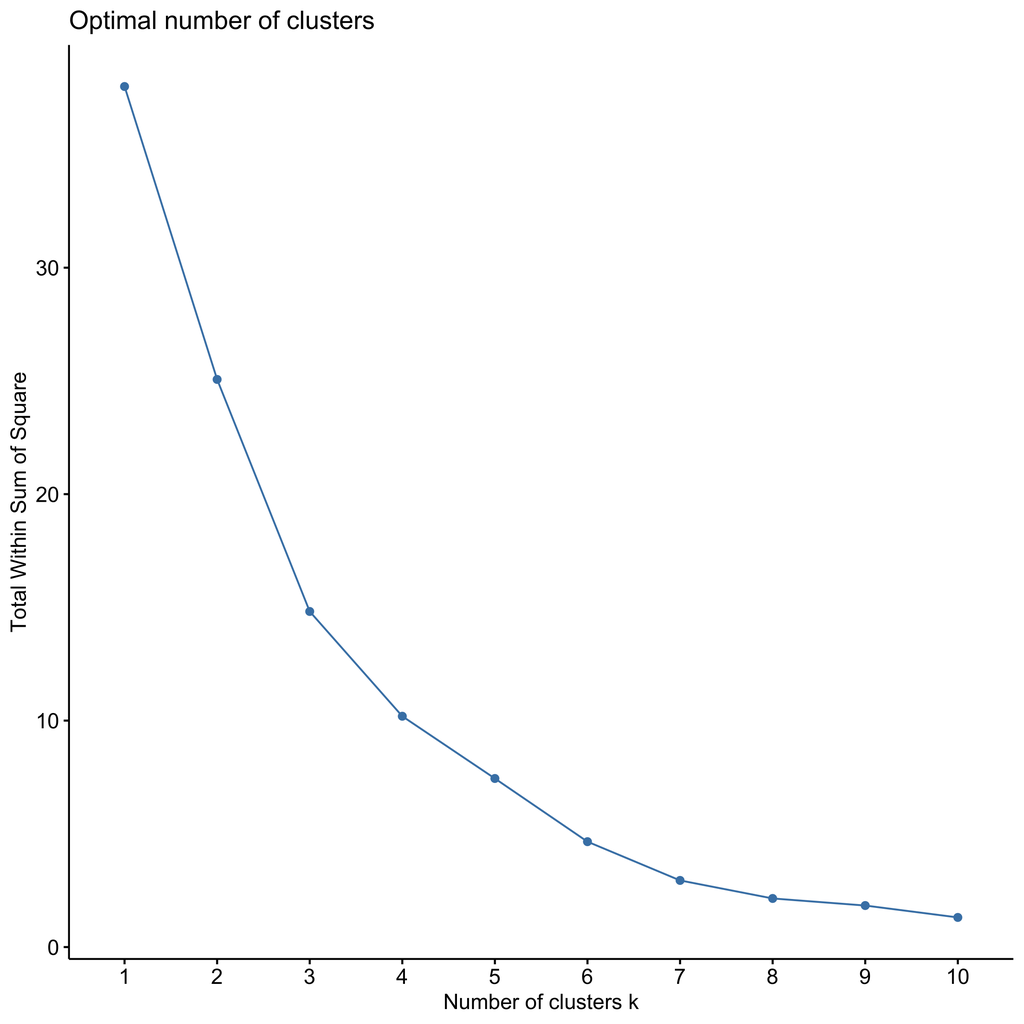

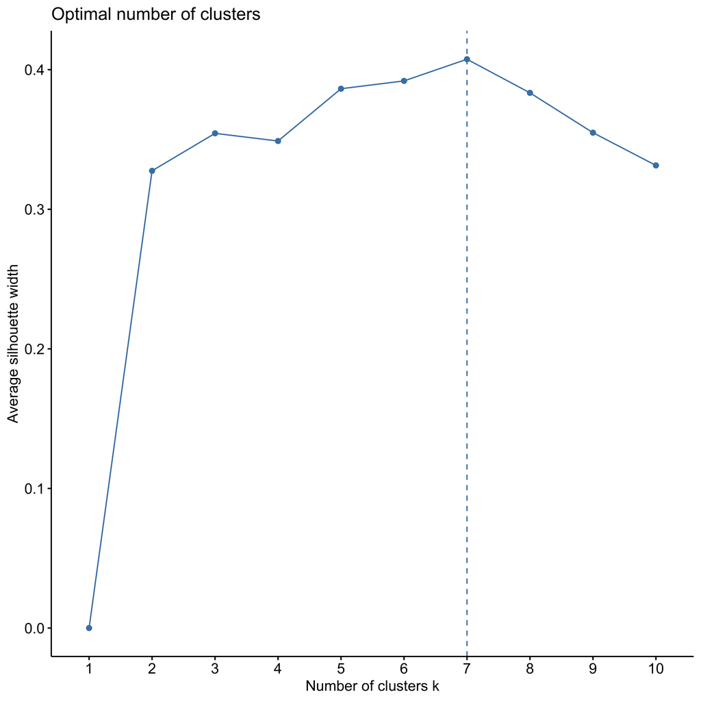

```r
# Prepare emitter-level data: keep main emitters, degree, and total funding (SEK)
mm_nodes <- nodes %>%
  filter(main_emitter) %>%
  select(name, degree, sek_tot)

# Build scaled input: degree and log(SEK)
cluster_deg_nodes <- mm_nodes %>%
  mutate(log_sek = log(sek_tot)) %>%
  select(degree, log_sek) %>%
  scale()

# Diagnostics (WSS and silhouette) to choose k
factoextra::fviz_nbclust(cluster_deg_nodes, kmeans, method = "wss")
factoextra::fviz_nbclust(cluster_deg_nodes, kmeans, method = "silhouette")

# K-means with k = 7 (per diagnostics)
deg_kl <- kmeans(cluster_deg_nodes, centers = 7)

# Attach cluster labels and tidy for plotting
emitter_nodes <- mm_nodes %>%
  mutate(msek = round(sek_tot/1e6, 1),
    cluster = deg_kl$cluster) %>%
  select(name, cluster, degree, msek) %>%
  arrange(cluster)
```

## 6.5 Plotting the Clusters (Figure 6 in paper)

C1: Moderately Central, Highly Engaged Collaborators

(Medium collaboration, high engagement)

```
•   Uniper, Boliden, Stockholm Exergi, St1

•   Degree: 8–11 \| Engagement: high
```

C2: Highly Central, Low-Engagement Collaborators

(High collaboration, low engagement)

```
•   Preem, Vargön Alloys, Sysav, E.ON

•   Degree: 8–16 \| Engagement: low
```

C3: Highly Central, Highly Engaged Anchors

(High collaboration, very high engagement)

```
•   Heidelberg Materials, Vattenfall, LKAB

•   Degree: 14–21 \| Engagement: very high
```

C4: Extremely Central, Low-Engagement Actor

(Very high collaboration, low engagement)

```
•   Höganäs

•   Degree: 30 \| Engagement: low
```

C5: Low-Centrality, Selectively Engaged Actors

(Low collaboration, moderate-to-high engagement)

```
•   Kubal, Tekniska verken i Linköping, Borealis

•   Degree: 0–2 \| Engagement: selective
```

C6: Peripheral, Minimally Engaged Actors

(Low collaboration, very low engagement)

```
•   Renova, SMA Mineral

•   Degree: 5–9 \| Engagement: minimal
```

C7: Moderately Central, Moderately Engaged Actors

(Intermediate collaboration and engagement)

```
•   Outokumpu, Nordkalk, SSAB

•   Degree: 10–19 \| Engagement: moderate
```

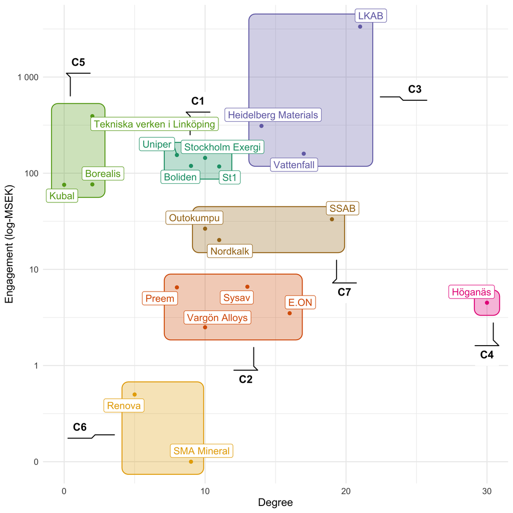

Figure 4: Main emitters clustered into C1–C7 by collaborative embeddedness (degree) and public funding engagement (MSEK, log scale). Shaded hulls show clusters; points are firms; labels display firm names.

```r
emitter_nodes %>%
  mutate(cluster = as.factor(cluster)) %>%
  ggplot(aes(degree, msek,
             color = cluster,
             label= name))+
  geom_mark_rect(aes(fill = cluster, label = paste0("C", cluster)))+
  geom_point()+
  geom_label_repel(show.legend = F)+
  scale_y_log10(labels = scales::number_format(accuracy = 1)) +
#  scale_color_colorblind(name = "Cluster")+
  scale_color_brewer(palette = "Dark2")+
  scale_fill_brewer(palette = "Dark2")+
  theme_minimal()+
  theme(plot.background = element_rect(colour = "white"))+
  labs(x= "Degree", y = "Engagement (log-MSEK)")+
  theme(legend.position = "none",
        text = element_text(size = 12))
```

# 7 Construction of the Role Typology from Cluster Analyses A–C

The role typology is constructed by combining results from three analytically distinct clustering steps (A–C) and translating their joint patterns into four higher-level strategic roles. This section explains how the two tables produced by the code above are used together for this purpose: (i) tab_ABC, which documents each incumbent’s cluster memberships and descriptive labels across A–C, and (ii) the typology table (discussion_typology.xlsx), which maps incumbents to the final four roles used in the main text. Read together, these tables make transparent the inferential chain from empirical clustering results to the interpretive role typology.

## 7.1 Generating the cross-analysis table (tab_ABC)

[output not shown]

## 7.2 From A–B–C configurations to roles: the logic of the typology table

The second table (typology, loaded from discussion_typology.xlsx) records the final role assignment for each incumbent. The role typology is not produced via an additional clustering step or a formal algorithmic rule. Rather, the typology table is constructed through a comparative, configuration-based synthesis where the A–B–C configuration patterns observed in tab_ABC are grouped into four higher-level roles.

[output not shown]

In this synthesis, the three analyses are treated as complementary lenses that jointly characterise incumbent role performance within the transformative policy mission. Analysis A (emissions–engagement proportionality) captures whether incumbents’ engagement in mission-oriented policy instruments is commensurate with their material responsibility for emissions. Analysis B (pathway–scope orientation) captures how firms translate mission directionality into strategic choices regarding technological pathways and the emissions scope they target. Analysis C (collaboration–engagement positioning) captures how firms position themselves within collaborative project structures, combining network embeddedness with engagement intensity.

Rather than deriving roles mechanically from specific cluster combinations, roles are assigned by identifying dominant and recurring orientations across these three domains. Explanatory power in this approach derives from the consistency—or systematic tension—between a firm’s positions across A–C, rather than from any single cluster membership.

In practical terms, the role typology can be understood as a configuration-based mapping that takes the empirical information contained in firms’ A–B–C profiles as input and produces higher-level role categories as interpretive summaries of similar strategic orientations. The appendix therefore replaces a purely tabular presentation with firm-level role motivations, making explicit how each assignment follows from the observed A–B–C configuration in relation to the guiding questions of responsibility and commitment (A), strategic orientation (B), and system positioning (C).

### 7.2.1 Transformative frontrunners

Transformative frontrunners are incumbents whose configurations indicate strong engagement relative to their emissions responsibility, prioritisation of pathways that directly target core process emissions, and collaborative positions that support coordination and scaling. These firms do not share identical A–B–C combinations but converge on a common strategic orientation toward system-level transformation.

[output not shown]

Together, these firms enact transformation either by reconfiguring core production processes or by anchoring infrastructures that are indispensable for deep decarbonisation at system level.

### 7.2.2 System enablers

System enablers are incumbents whose primary contribution lies in enabling other actors’ decarbonisation through shared infrastructures, rather than transforming their own core production processes. They combine high engagement with infrastructure-oriented pathways and central coordinating positions.

[output not shown]

These firms act as system builders whose strategic relevance lies in structuring interdependencies, reducing coordination failures, and enabling scaling across sectors.

### 7.2.3 Adaptive followers

Adaptive followers constitute the most heterogeneous role category. They engage with the mission through selective, incremental, or preparatory activities, without committing to comprehensive transformation of core production systems. Their configurations reflect partial alignment across A–C and diverse adaptive strategies.

[output not shown]

Collectively, these firms illustrate diverse adaptive responses that may support learning and incremental alignment with the mission, while also allowing core decarbonisation challenges to remain partially unresolved.

### 7.2.4 Peripheral bystanders

Peripheral bystanders remain marginal across all three analytical domains. Their configurations show low engagement relative to emissions responsibility, peripheral collaborative positioning, and limited or preparatory pathway orientations.

```
•   SMA Mineral exhibits minimal engagement, peripheral network positioning, and CCS-related activities that remain exploratory. Its configuration indicates weak integration into mission-oriented coordination and scaling dynamics.

•   Renova similarly combines low engagement with peripheral positioning, participating primarily in infrastructure-oriented CCS initiatives without sustained project leadership or strategic commitment.
```

These firms represent the lower boundary of incumbent engagement within the mission context, highlighting limits to the reach of current policy instruments.

# 8 Appendix

| P | Organisation | Title | Pathway | Scope |
| --- | --- | --- | --- | --- |
| 1 | Boliden | Slag reduction with hydrogen | Electricity and hydrogen | Scope 1 |
| 2 | Boliden | Fossil-free underground mine | Electricity and hydrogen | Scope 1 |
| 3 | Boliden | Heat exchanger system mine ventilation Kankberg mine | Energy efficiency | Scope 2 |
| 4 | Boliden | Ecolink - Utilize waste heat for Skellefteå's district heating network | Energy efficiency | Others |
| 5 | Borealis | Plastic recycling refinery in Stenungsund | Recycling | Scope 1 |
| 6 | Borealis | Plastic recycling refinery in Stenungsund | Recycling | Scope 1 |
| 7 | E.ON | Carbon Network South Sweden (CNetSS) | CCS | Infrastructure |
| 8 | E.ON | Carbon Network South Sweden (CNetSS) – phase 3 | CCS | Infrastructure |
| 9 | E.ON | Delivery of biogas to industrial customer in southern Skåne | Biofuels and biomass | Others |
| 10 | E.ON | Large-scale production of biochar as a renewable raw material in the fossil-free value chain within the iron and steel industry | Biofuels and biomass | Others |
| 11 | E.ON | Feasibility study for bio-CCS at Åby and Händelö combined heat and power plant | BECSS | Scope 1 |
| 12 | E.ON | bioCCS at the new combined heat and power plant in Malmö Energy Port | BECSS | Scope 1 |
| 13 | E.ON | Energy efficiency | Energy efficiency | Others |
| 14 | Heidelberg Materials | CemZero - Heat transfer with plasma in rotary kilns | CCS | Scope 1 |
| 15 | Heidelberg Materials | CemZero – Carbon dioxide-free products with electrified manufacturing – reactivity of cement clinker with secondary additives | CCS | Scope 1 |
| 16 | Heidelberg Materials | CemZero-Fundamental properties of standalone plasma and plasma in combination with calcium-based bed materials in rotary kiln. | CCS | Scope 1 |
| 17 | Heidelberg Materials | Feasibility study CCS Slite – the foundation for the world's first climate-positive cement factory | CCS | Scope 1 |
| 18 | Heidelberg Materials | Feasibility study Slite CCS - on the way to the world's first climate-neutral cement factory | CCS | Scope 1 |
| 19 | Heidelberg Materials | Design preparations FEED Slite CCS – towards zero net emissions 2030 | CCS | Scope 1 |
| 20 | Heidelberg Materials | Radiobased calcination determination in the production of cement and burnt lime | Energy efficiency | Scope 1 |
| 21 | Heidelberg Materials | Installation of silo capacity for the production of concrete with lower climate impact. | Energy efficiency | Scope 1 |
| 22 | Heidelberg Materials | Installation of silo capacity for the production of concrete with lower climate impact. | Energy efficiency | Scope 1 |
| 23 | Höganäs | Large-scale production of biochar as a renewable raw material in the fossil-free value chain within the iron and steel industry | Biofuels and biomass | Scope 1 |
| 24 | Höganäs | Pilot study with carbon dioxide neutral biochar in the Höganäs process | Biofuels and biomass | Scope 1 |
| 25 | Höganäs | Carbon Network South Sweden (CNetSS) | CCS | Infrastructure |
| 26 | Höganäs | Increased energy recovery for district heating | Energy efficiency | Others |
| 27 | Kubal | Conversion of preheating of anodes before casting | Electricity and hydrogen | Scope 1 |
| 28 | Kubal | Co-location of primary production and remelting of aluminum products | Recycling | Scope 1 |
| 29 | LKAB | HYBRIT pilot project - Hydrogen storage in underground caverns with LRC technology | Electricity and hydrogen | Scope 1 |
| 30 | LKAB | HYBRIT (Hydrogen Breakthrough Ironmaking Technology) - research project | Electricity and hydrogen | Scope 1 |

[output cut: 67 more lines]